# R Notebook

```r
if (!require('dplyr')) install.packages('dplyr')
```

```r
if (!require('ggplot2')) install.packages('ggplot2')
```

**Principles of Data Visualization and Introduction to ggplot2**

I have provided you with data about the 5,000 fastest growing companies in the US, as compiled by Inc. magazine. lets read this in:

```r
inc <- read.csv("https://raw.githubusercontent.com/charleyferrari/CUNY_DATA_608/master/module1/Data/inc5000_data.csv", header= TRUE)
```

And lets preview this data:

```r
head(inc)
```

```
##   Rank                         Name Growth_Rate   Revenue
## 1    1                         Fuhu      421.48 1.179e+08
## 2    2        FederalConference.com      248.31 4.960e+07
## 3    3                The HCI Group      245.45 2.550e+07
## 4    4                      Bridger      233.08 1.900e+09
## 5    5                       DataXu      213.37 8.700e+07
## 6    6 MileStone Community Builders      179.38 4.570e+07
##                       Industry Employees         City State
## 1 Consumer Products & Services       104   El Segundo    CA
## 2          Government Services        51     Dumfries    VA
## 3                       Health       132 Jacksonville    FL
## 4                       Energy        50      Addison    TX
## 5      Advertising & Marketing       220       Boston    MA
## 6                  Real Estate        63       Austin    TX
```

```r
summary(inc)
```

```
##       Rank                          Name       Growth_Rate
##  Min.   :   1   (Add)ventures         :   1   Min.   :  0.340
##  1st Qu.:1252   @Properties           :   1   1st Qu.:  0.770
##  Median :2502   1-Stop Translation USA:   1   Median :  1.420
##  Mean   :2502   110 Consulting        :   1   Mean   :  4.612
##  3rd Qu.:3751   11thStreetCoffee.com  :   1   3rd Qu.:  3.290
##  Max.   :5000   123 Exteriors         :   1   Max.   :421.480
##                 (Other)               :4995
##     Revenue                                  Industry      Employees
##  Min.   :2.000e+06   IT Services                 : 733   Min.   :    1.0
##  1st Qu.:5.100e+06   Business Products & Services: 482   1st Qu.:   25.0
##  Median :1.090e+07   Advertising & Marketing     : 471   Median :   53.0
##  Mean   :4.822e+07   Health                      : 355   Mean   :  232.7
##  3rd Qu.:2.860e+07   Software                    : 342   3rd Qu.:  132.0
##  Max.   :1.010e+10   Financial Services          : 260   Max.   :66803.0
##                      (Other)                     :2358   NA's   :12
##             City          State
##  New York     : 160   CA     : 701
##  Chicago      :  90   TX     : 387
##  Austin       :  88   NY     : 311
##  Houston      :  76   VA     : 283
##  San Francisco:  75   FL     : 282
##  Atlanta      :  74   IL     : 273
##  (Other)      :4438   (Other):2764
```

Think a bit on what these summaries mean. Use the space below to add some more relevant non-visual exploratory information you think helps you understand this data:

```r
# Insert your code here, create more chunks as necessary
countByState <- plyr::count(inc, c("State"))
countByState <- plyr::arrange(countByState, freq)
countByState
```

```
##    State freq
## 1     PR    1
## 2     AK    2
## 3     WV    2
## 4     WY    2
## 5     SD    3
## 6     MT    4
## 7     NM    5
## 8     VT    6
## 9     HI    7
## 10    AR    9
## 11    ND   10
## 12    MS   12
## 13    ME   13
## 14    DE   16
```

[output cut: 38 more lines]

## Question 1

Create a graph that shows the distribution of companies in the dataset by State (ie how many are in each state). There are a lot of States, so consider which axis you should use. This visualization is ultimately going to be consumed on a ‘portrait’ oriented screen (ie taller than wide), which should further guide your layout choices.

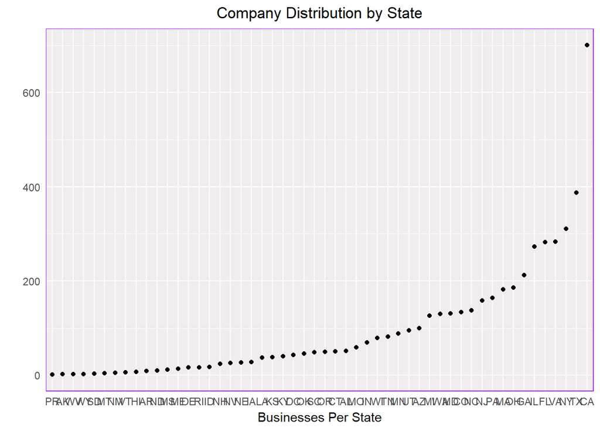

```r
countByState$State <- factor(countByState$State, levels=unique(as.character(countByState$State)) )

g1 <- ggplot(data=countByState, aes(x=State, y=freq))
g1 <- g1 + theme(axis.ticks=element_blank(),
                 plot.title = element_text(hjust = 0.5),
                 panel.border = element_rect(color="purple", fill=NA),
                 panel.background=element_rect(fill="#efeded"),
                 panel.grid.major.y=element_line(color="white", size=0.5),
                 panel.grid.major.x=element_line(color="white", size=0.5))

g1 <- g1 + geom_point()
g1 <- g1 + scale_x_discrete(breaks=waiver())
g1 <- g1 + scale_y_continuous(breaks=c(seq(0,800,by=200)))
g1 <- g1 + labs(title="Company Distribution by State", x="Businesses Per State", y="")
g1
```

## Quesiton 2

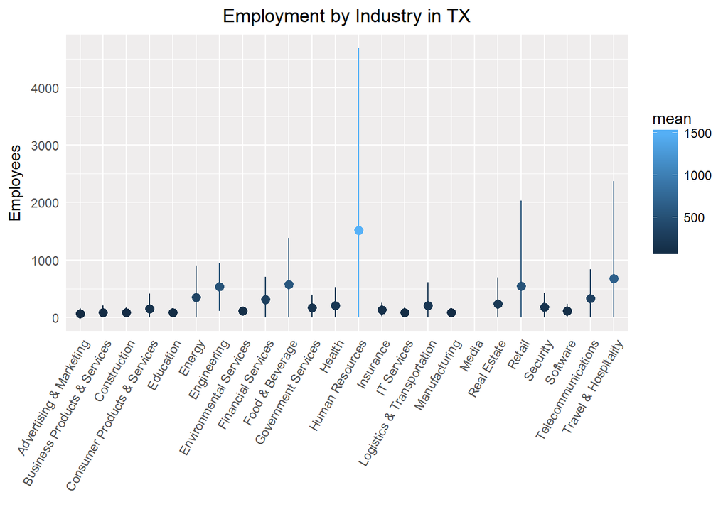

```r
# Answer Question 2 here
stateId <- countByState$State[nrow(countByState)-(1)]
data <- dplyr::filter(inc, State == stateId)
ok <- complete.cases(data)
completeStateData <- data[ok,]

employmentByIndustry <- plyr::ddply(completeStateData, c("State", "Industry"), plyr::summarize, mean = mean(Employees), sd = sd(Employees), .inform=TRUE)

# Put a floor on the minimum (-1 stdev) at zero
employmentByIndustry$min <- employmentByIndustry$mean - employmentByIndustry$sd
employmentByIndustry$min[employmentByIndustry$min < 0] = 0

completeStateDataMSD <- plyr::join(completeStateData, employmentByIndustry, by=c("State", "Industry"))

g2 <- ggplot(data=employmentByIndustry, aes(x=Industry, y=mean, color=mean))
g2 <- g2 + theme(axis.ticks=element_blank(),
                 axis.text.x=element_text(angle=60,hjust=1),
                 plot.title = element_text(hjust = 0.5),
                 panel.background=element_rect(fill="#efeded"),
                 panel.grid.major.y=element_line(color="white", size=0.5),
                 panel.grid.major.x=element_line(color="white", size=0.5))
g2 <- g2 + geom_pointrange(aes(ymin=min, ymax=mean + sd))
g2 <- g2 + labs(title=sprintf("Employment by Industry in %s", as.character(stateId)), x="", y="Employees")
g2
```

## Question 3

Now imagine you work for an investor and want to see which industries generate the most revenue per employee. Create a chart that makes this information clear. Once again, the distribution per industry should be shown.

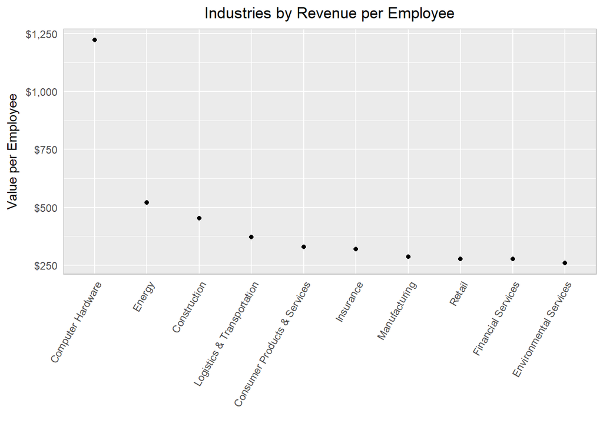

```r
ok <- complete.cases(inc)
completeData <- inc[ok,]
avgEmpRevByInd <- plyr::ddply(completeData, c("Industry"), plyr::summarize, totalEmployees = sum(Employees), totalRevenue = sum(Revenue), .inform=TRUE)
avgEmpRevByInd$meanRevPerEmp <- avgEmpRevByInd$totalRevenue / avgEmpRevByInd$totalEmployees
avgEmpRevByInd <- plyr::arrange(avgEmpRevByInd, meanRevPerEmp, decreasing=TRUE)
avgEmpRevByInd$Industry <- factor(avgEmpRevByInd$Industry, levels=unique(as.character(avgEmpRevByInd$Industry)) )
avgEmpRevByInd <- head(avgEmpRevByInd, n=10)

dollarFormat <- function(l) {
  l <- prettyNum(l / 1000, big.mark=",", scientific = FALSE)
  return(sprintf("$%s", l))
}

# Visualize
g3 <- ggplot(data=avgEmpRevByInd, aes(x=Industry, y=meanRevPerEmp))
g3 <- g3 + theme(axis.ticks=element_blank(),
                 axis.text.x=element_text(angle=60,hjust=1),
                 panel.border = element_rect(color="gray", fill=NA),
                 plot.title = element_text(hjust = 0.5),
                 panel.grid.major.y=element_line(color="white", size=0.5),
                 panel.grid.major.x=element_line(color="white", size=0.5))
g3 <- g3 + geom_point()
g3 <- g3 + scale_y_continuous(labels=dollarFormat)
g3 <- g3 + labs(title=sprintf("Industries by Revenue per Employee"), x="", y="Value per Employee")
g3
```